# ZAD 1

Proszę pobrać plik customers_mall.csv, zawierający informacje o klientach pewnego centrum handlowego. Pierwsza kolumna przedstawia ich zarobki (w tysiącach), w drugiej zaś znajduje się punktowa ocena wydatków (od 0 do 100) każdego z klientów. Proszę dokonać klasteryzacji zbioru z użyciem algorytmu k-means. Uzyskane wyniki należy zwizualizować, ocenić i opisać. Wskazane jest zarekomendowanie odpowiedniej ilości klastrów.

```python
from google.colab import drive
import pandas as pd
drive.mount('/content/drive')
df = pd.read_csv('/content/drive/My Drive/Colab Notebooks/Lab06/customers_mall.csv',sep = ';')
print(f'Rows = {df.shape[0]}')
```

```
Rows = 200
```

```python
df
```

|  | Annual Income | Spending Score |
| --- | --- | --- |
| 0 | 15 | 39 |
| 1 | 15 | 81 |
| 2 | 16 | 6 |
| 3 | 16 | 77 |
| 4 | 17 | 4 |
| ... | ... | ... |
| 195 | 120 | 79 |
| 196 | 126 | 28 |
| 197 | 126 | 74 |
| 198 | 137 | 18 |
| 199 | 137 | 83 |

200 rows × 2 columns

```python
df.describe()
```

|  | Annual Income | Spending Score |
| --- | --- | --- |
| count | 200.000000 | 200.000000 |
| mean | 60.560000 | 46.465000 |
| std | 26.264721 | 28.220396 |
| min | 15.000000 | 1.000000 |
| 25% | 41.500000 | 21.000000 |
| 50% | 61.500000 | 47.500000 |
| 75% | 78.000000 | 72.000000 |
| max | 137.000000 | 99.000000 |

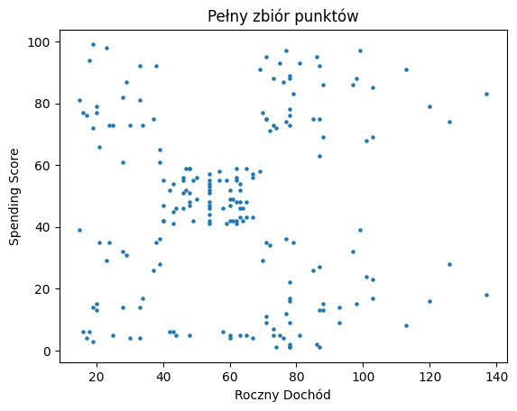

```python
import matplotlib.pyplot as plt
plt.scatter(df.iloc[:,0],df.iloc[:,1],s=5)
plt.xlabel('Roczny Dochód')
plt.ylabel('Spending Score')
plt.title(f'Pełny zbiór punktów')
plt.show()
```

```python
from sklearn.preprocessing import StandardScaler
scaler = StandardScaler()
df_scaled = pd.DataFrame(scaler.fit_transform(df),columns = ['Annual Income' ,	'Spending Score'])
df_scaled.describe()
```

|  | Annual Income | Spending Score |
| --- | --- | --- |
| count | 2.000000e+02 | 2.000000e+02 |
| mean | -2.131628e-16 | -1.487699e-16 |
| std | 1.002509e+00 | 1.002509e+00 |
| min | -1.738999e+00 | -1.615112e+00 |
| 25% | -7.275093e-01 | -9.046260e-01 |
| 50% | 3.587926e-02 | 3.676764e-02 |
| 75% | 6.656748e-01 | 9.071127e-01 |
| max | 2.917671e+00 | 1.866268e+00 |

## Rekomendacja odpowiedniej ilości klastrów

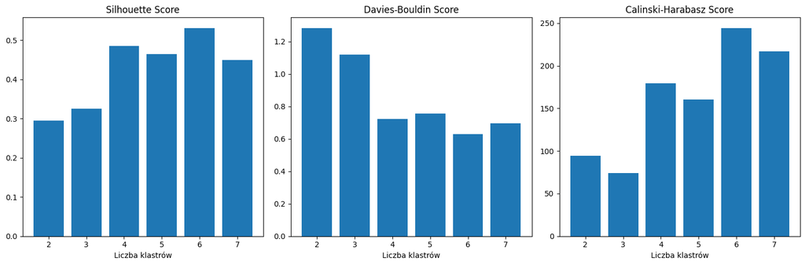

```python
from sklearn.cluster import KMeans
from sklearn import metrics

d = {'Silhouette':[], 'DB':[], 'CH':[]}

for i in range(2,8):
  model = KMeans(n_clusters=i)
  model.fit(df_scaled)
  labels = model.labels_
  d['Silhouette'].append(metrics.silhouette_score(df_scaled, labels))
  d['DB'].append(metrics.davies_bouldin_score(df_scaled, labels))
  d['CH'].append(metrics.calinski_harabasz_score(df_scaled, labels))

fig, axs = plt.subplots(1, 3, figsize=(15, 5))
x_values = range(2,8)
axs[0].bar(x_values, d['Silhouette'])
axs[0].set_title('Silhouette Score')

axs[1].bar(x_values, d['DB'])
axs[1].set_title('Davies-Bouldin Score')

axs[2].bar(x_values, d['CH'])
axs[2].set_title('Calinski-Harabasz Score')

for i in range(3):
  axs[i].set_xlabel('Liczba klastrów')

plt.tight_layout()
plt.show()
```

## Wnioski

```python
model = KMeans(n_clusters=5)
model.fit(df_scaled)

print('Centra klastrów:')
print(scaler.inverse_transform(model.cluster_centers_))
```

```
Centra klastrów:
[[28.57692308 16.57692308]
 [54.81690141 49.25352113]
 [84.25       13.54545455]
 [86.59459459 81.7027027 ]
 [25.72727273 79.36363636]]
```

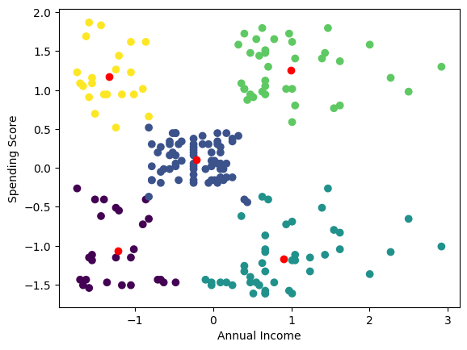

```python
plt.scatter(df_scaled.iloc[:,0],df_scaled.iloc[:,1],c=model.labels_)
plt.scatter(model.cluster_centers_[:,0], model.cluster_centers_[:,1], c='red')
plt.xlabel('Annual Income')
plt.ylabel('Spending Score')
plt.show()
```

# ZAD 2

W pliku planets.csv mają państwo zbiór 778 spośród ponad 5000 znanych egzoplanet (planet pozasłonecznych) pozyskany z bazy danych NASA (https://exoplanetarchive.ipac.caltech.edu/index.html). Proszę dokonać klasteryzacji tego zbioru kilkoma sposobami, ocenić wyniki za pomocą odpowiednich metryk, wybrać dowolny z wyników i jego rezultaty (czym się charakteryzują klastry).

Poniżej znajduje się opis kolumn do zestawu danych:

```
     pl_name:        Planet Name,
     pl_orbper:      Orbital Period [days]',
     pl_orbsmax:     Orbit Semi-Major Axis [au]),
     pl_rade:        Planet Radius [Earth Radius],
     pl_masse:       Planet Mass [Earth Mass],
     pl_orbeccen:    Eccentricity,
     pl_eqt:         Equilibrium Temperature [K],
     st_teff:        Stellar Effective Temperature [K],
     st_mass:        Stellar Mass [Solar mass],
     sy_dist:        Distance [pc]
```

```python
df = pd.read_csv('/content/drive/My Drive/Colab Notebooks/Lab06/planets.csv',sep = ',')
```

```python
df
```

|  | pl_name | pl_orbper | pl_orbsmax | pl_rade | pl_masse | pl_orbeccen | pl_eqt | st_teff | st_mass | sy_dist |
| --- | --- | --- | --- | --- | --- | --- | --- | --- | --- | --- |
| 0 | 55 Cnc e | 0.736544 | 0.01544 | 2.080 | 7.81000 | 0.061 | 1958 | 5234.0 | 0.91 | 12.5855 |
| 1 | AU Mic b | 8.463000 | 0.06450 | 4.070 | 17.00000 | 0.000 | 593 | 3700.0 | 0.50 | 9.7221 |
| 2 | AU Mic c | 18.859019 | 0.11010 | 3.240 | 13.60000 | 0.000 | 454 | 3700.0 | 0.50 | 9.7221 |
| 3 | BD+20 594 b | 41.685500 | 0.24100 | 2.230 | 16.30000 | 0.000 | 546 | 5766.0 | 0.96 | 179.4610 |
| 4 | CoRoT-10 b | 13.240600 | 0.10550 | 10.870 | 874.00000 | 0.530 | 600 | 5075.0 | 0.89 | 338.3860 |
| ... | ... | ... | ... | ... | ... | ... | ... | ... | ... | ... |
| 773 | XO-5 b | 4.187756 | 0.05150 | 12.780 | 378.20000 | 0.000 | 1230 | 5430.0 | 1.04 | 276.2110 |
| 774 | XO-6 b | 3.765001 | 0.08150 | 23.203 | 1398.45200 | 0.000 | 1577 | 6720.0 | 1.47 | 235.4790 |
| 775 | XO-7 b | 2.864142 | 0.04421 | 15.390 | 225.34147 | 0.038 | 1743 | 6250.0 | 1.41 | 234.1490 |
| 776 | pi Men c | 6.267900 | 0.06839 | 2.042 | 4.82000 | 0.000 | 1170 | 6037.0 | 1.09 | 18.2702 |
| 777 | pi Men c | 6.268340 | 0.06702 | 2.060 | 4.52000 | 0.000 | 1147 | 5870.0 | 1.02 | 18.2702 |

778 rows × 10 columns

```python
df.describe()
```

|  | pl_orbper | pl_orbsmax | pl_rade | pl_masse | pl_orbeccen | pl_eqt | st_teff | st_mass | sy_dist |
| --- | --- | --- | --- | --- | --- | --- | --- | --- | --- |
| count | 778.000000 | 778.000000 | 778.000000 | 778.000000 | 778.000000 | 778.000000 | 778.000000 | 778.000000 | 778.000000 |
| mean | 19.318080 | 0.089892 | 9.991374 | 367.210044 | 0.083592 | 1237.406170 | 5463.256337 | 1.006311 | 336.709493 |
| std | 147.168764 | 0.217884 | 5.872213 | 685.849443 | 0.130941 | 549.755232 | 951.087857 | 0.324636 | 345.862713 |
| min | 0.179715 | 0.005800 | 0.510000 | 0.070000 | 0.000000 | 134.000000 | 2988.000000 | 0.150000 | 6.531270 |
| 25% | 2.815264 | 0.038155 | 3.150000 | 15.050000 | 0.000000 | 797.500000 | 5056.500000 | 0.830000 | 108.729750 |
| 50% | 4.014884 | 0.050600 | 11.555500 | 177.982400 | 0.030000 | 1244.000000 | 5630.000000 | 1.020000 | 252.031000 |
| 75% | 8.878242 | 0.080000 | 14.238750 | 390.930900 | 0.112750 | 1623.750000 | 6058.750000 | 1.210000 | 448.088250 |
| max | 3650.000000 | 4.500000 | 23.430000 | 6388.100000 | 0.920000 | 4050.000000 | 10170.000000 | 2.520000 | 4483.050000 |

```python
df.columns[1:]
```

```
Index(['pl_orbper', 'pl_orbsmax', 'pl_rade', 'pl_masse', 'pl_orbeccen',
       'pl_eqt', 'st_teff', 'st_mass', 'sy_dist'],
      dtype='object')
```

```python
import numpy as np
for col in df.columns[1:]:
  mean = np.mean(df[col])
  std = np.std(df[col])
  lower_bound = mean - 3*std
  upper_bound = mean + 3*std
  df = df[(df[col] >= lower_bound) & (df[col] <= upper_bound)]

print(f'Liczba rzędów bo usunięciu outlierów: {df.shape[0]}')
```

```
Liczba rzędów bo usunięciu outlierów: 710
```

```python
df.shape
```

```
(710, 10)
```

```python
df.iloc[:,1:]
```

|  | pl_orbper | pl_orbsmax | pl_rade | pl_masse | pl_orbeccen | pl_eqt | st_teff | st_mass | sy_dist |
| --- | --- | --- | --- | --- | --- | --- | --- | --- | --- |
| 0 | 0.736544 | 0.01544 | 2.080 | 7.81000 | 0.061 | 1958 | 5234.0 | 0.91 | 12.5855 |
| 1 | 8.463000 | 0.06450 | 4.070 | 17.00000 | 0.000 | 593 | 3700.0 | 0.50 | 9.7221 |
| 2 | 18.859019 | 0.11010 | 3.240 | 13.60000 | 0.000 | 454 | 3700.0 | 0.50 | 9.7221 |
| 3 | 41.685500 | 0.24100 | 2.230 | 16.30000 | 0.000 | 546 | 5766.0 | 0.96 | 179.4610 |
| 5 | 2.994330 | 0.04360 | 16.030 | 740.51000 | 0.000 | 1657 | 6440.0 | 1.27 | 655.0370 |
| ... | ... | ... | ... | ... | ... | ... | ... | ... | ... |
| 773 | 4.187756 | 0.05150 | 12.780 | 378.20000 | 0.000 | 1230 | 5430.0 | 1.04 | 276.2110 |
| 774 | 3.765001 | 0.08150 | 23.203 | 1398.45200 | 0.000 | 1577 | 6720.0 | 1.47 | 235.4790 |
| 775 | 2.864142 | 0.04421 | 15.390 | 225.34147 | 0.038 | 1743 | 6250.0 | 1.41 | 234.1490 |
| 776 | 6.267900 | 0.06839 | 2.042 | 4.82000 | 0.000 | 1170 | 6037.0 | 1.09 | 18.2702 |
| 777 | 6.268340 | 0.06702 | 2.060 | 4.52000 | 0.000 | 1147 | 5870.0 | 1.02 | 18.2702 |

710 rows × 9 columns

```python
from sklearn.preprocessing import MinMaxScaler
scaler = MinMaxScaler()
df_scaled = pd.DataFrame(scaler.fit_transform(df.iloc[:,1:]),columns = df.columns[1:])
df_scaled.describe()
```

|  | pl_orbper | pl_orbsmax | pl_rade | pl_masse | pl_orbeccen | pl_eqt | st_teff | st_mass | sy_dist |
| --- | --- | --- | --- | --- | --- | --- | --- | --- | --- |
| count | 710.000000 | 710.000000 | 710.000000 | 710.000000 | 710.000000 | 710.000000 | 710.000000 | 710.000000 | 710.000000 |
| mean | 0.092839 | 0.179351 | 0.405627 | 0.116160 | 0.153643 | 0.404902 | 0.499749 | 0.477014 | 0.240281 |
| std | 0.122986 | 0.148942 | 0.258595 | 0.156437 | 0.220905 | 0.204156 | 0.189523 | 0.178514 | 0.211945 |
| min | 0.000000 | 0.000000 | 0.000000 | 0.000000 | 0.000000 | 0.000000 | 0.000000 | 0.000000 | 0.000000 |
| 25% | 0.033920 | 0.097624 | 0.108639 | 0.005889 | 0.000000 | 0.238913 | 0.415108 | 0.377143 | 0.076256 |
| 50% | 0.048525 | 0.134120 | 0.478534 | 0.069322 | 0.052874 | 0.409509 | 0.544784 | 0.485714 | 0.189630 |
| 75% | 0.099833 | 0.202943 | 0.599040 | 0.147785 | 0.217241 | 0.555933 | 0.631910 | 0.604286 | 0.332575 |
| max | 1.000000 | 1.000000 | 1.000000 | 1.000000 | 1.000000 | 1.000000 | 1.000000 | 1.000000 | 1.000000 |

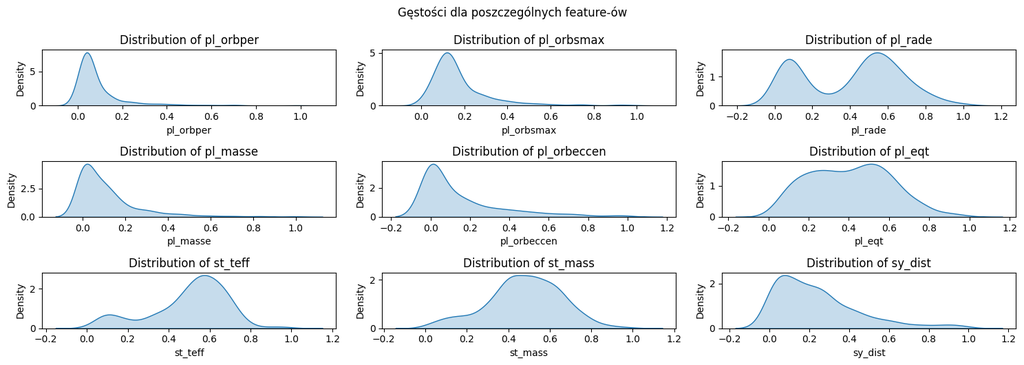

```python
from seaborn import kdeplot

fig, axs = plt.subplots(3, 3, figsize=(15, 5))
i = 0
for col in df_scaled.columns:
    row = i // 3
    col_index = i % 3
    kdeplot(data=df_scaled, x=col, fill=True, ax=axs[row, col_index],)
    i += 1
    axs[row, col_index].set_title(f'Distribution of {col}')

fig.tight_layout()
fig.suptitle('Gęstości dla poszczególnych feature-ów', y=1.05)
plt.show()
```

```python
#  Lepiej zrobic normalizacje min-max
#  --> jak mamy histogramy: dwa gaussy nalozone na sb albo uciety gauss, to standardowa moze się wykrzaczyć
```

```python
d = {name : {'Silhouette':[], 'DB':[], 'CH':[] } for name in ['kmeans', 'agglomerative']}

for nr_clusters in range(2,11):
  model_kmeans = KMeans(n_clusters = nr_clusters)
  model_kmeans.fit(df_scaled)
  labels = model_kmeans.labels_
  d['kmeans']['Silhouette'].append(metrics.silhouette_score(df_scaled, labels))
  d['kmeans']['DB'].append(metrics.davies_bouldin_score(df_scaled, labels))
  d['kmeans']['CH'].append(metrics.calinski_harabasz_score(df_scaled, labels))
```

```python
from sklearn.cluster import AgglomerativeClustering

for nr_clusters in range(2,11):
  model_agglomerative = AgglomerativeClustering(n_clusters=nr_clusters)
  model_agglomerative.fit(df_scaled)
  labels = model_agglomerative.labels_
  d['agglomerative']['Silhouette'].append(metrics.silhouette_score(df_scaled, labels))
  d['agglomerative']['DB'].append(metrics.davies_bouldin_score(df_scaled, labels))
  d['agglomerative']['CH'].append(metrics.calinski_harabasz_score(df_scaled, labels))
```

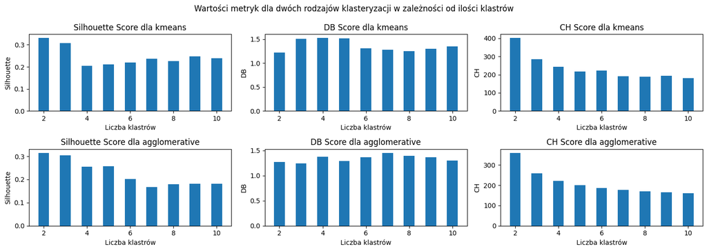

```python
fig, axs = plt.subplots(2, 3, figsize=(15, 5))
for idx, metric in enumerate(['Silhouette', 'DB', 'CH']):
    axs[0, idx].bar(range(2,11), d['kmeans'][metric], width = 0.5)
    axs[1, idx].bar(range(2,11), d['agglomerative'][metric], width = 0.5)

    axs[0, idx].set_title(f'{metric} Score dla kmeans')
    axs[1, idx].set_title(f'{metric} Score dla agglomerative')
    for row in range(2):
        axs[row, idx].set_xlabel('Liczba klastrów')
        axs[row, idx].set_ylabel(metric)

fig.tight_layout()
fig.suptitle('Wartości metryk dla dwóch rodzajów klasteryzacji w zależności od ilości klastrów', y=1.05)
plt.show()
```

## Wnioski

Na wykresie zauważamy, że dla obu metod klasteryzacji: k-średnich oraz aglomeracyjnej, metryki osiągają optymalne wartości dla dwóch klastrów.

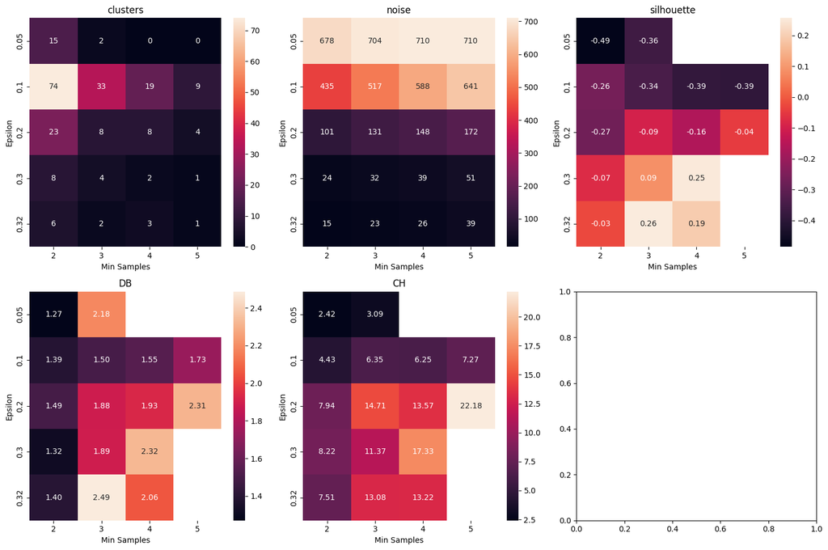

```python
from sklearn.cluster import DBSCAN
from seaborn import heatmap

epsilons = [0.05, 0.1, 0.2, 0.3, 0.32]
min_samples = [2, 3, 4, 5]
results = {}

for epsilon in epsilons:
    results[epsilon] = {}
    for min_sample in min_samples:
        model_dbscan = DBSCAN(eps=epsilon, min_samples=min_sample)
        model_dbscan.fit(df_scaled)
        labels = model_dbscan.labels_
        n_clusters_ = len(set(labels)) - (1 if -1 in labels else 0)
        n_noise_ = list(labels).count(-1)

        results[epsilon][min_sample] = {'clusters': n_clusters_, 'noise': n_noise_}

        if n_clusters_ > 1:
            results[epsilon][min_sample]['silhouette'] = metrics.silhouette_score(df_scaled, labels)
            results[epsilon][min_sample]['DB'] = metrics.davies_bouldin_score(df_scaled, labels)
            results[epsilon][min_sample]['CH'] = metrics.calinski_harabasz_score(df_scaled, labels)
        else:
            results[epsilon][min_sample]['silhouette'] = None
            results[epsilon][min_sample]['DB'] = None
            results[epsilon][min_sample]['CH'] = None

fig, axs = plt.subplots(2, 3, figsize=(15, 10))  # 2 rows, 3 columns
metrics_to_plot = ['clusters', 'noise', 'silhouette', 'DB', 'CH']
axs_flat = axs.flatten()

for i, metric in enumerate(metrics_to_plot):
    data = np.zeros((len(epsilons), len(min_samples)))
    for x, epsilon in enumerate(epsilons):
        for y, min_sample in enumerate(min_samples):
            data[x, y] = results[epsilon][min_sample].get(metric, np.nan)
    heatmap(data, annot=True, fmt=".2f" if metric in ['silhouette', 'DB', 'CH'] else ".0f", xticklabels=min_samples, yticklabels=epsilons, ax=axs_flat[i])
    axs_flat[i].set_xlabel('Min Samples')
    axs_flat[i].set_ylabel('Epsilon')
    axs_flat[i].set_title(f'{metric}')

plt.tight_layout()
plt.show()
```

## Wnioski

Wyniki opisujące klasteryzację przy pomocy DBSCAN na podstawie wartości epsilon oraz minimalnej liczby elementów potrzebnych do powstania zgrupowania zaprezentowane na heatmapach wskazują, że jest to metoda dużo gorsza dla tych danych. Spośród przedstawionych parametrów, daje ona najlepszy wynik dla : epsilon = 0.32, min_samples = 3. Dla takich parametrów, dzieli dane również na 2 klastry, podobnie jak poprzednie metody.

Spośród przetestowanych metod, optymalna wydaje się klasteryzacja za pomocą kmeans, dla dwóch klastrów. Dla niej uzyskałam najlepsze wartości analizowanych metryk. Wartości metryk dla takiego modelu przentują się następująco:

```python
model_kmeans = KMeans(n_clusters = 2)
model_kmeans.fit(df_scaled)
labels = model_kmeans.labels_
print(f'Silhouette: {metrics.silhouette_score(df_scaled, labels)}')
print(f'Davies-Bouldinc Score: {metrics.davies_bouldin_score(df_scaled, labels)}')
print(f'Carabasz-Halinski Score: {metrics.calinski_harabasz_score(df_scaled, labels)}')
```

```
Silhouette: 0.3308017100105429
Davies-Bouldinc Score: 1.216605318199412
Carabasz-Halinski Score: 402.27765514050327
```

# ZAD 3

Z użyciem algorytmu fuzzy clustering proszę zaproponować model dla podanego powyżej zestawu danych. Do uczenia należy wybrać wyłącznie połowę jego kolumn.

```python
!pip install scikit-fuzzy
```

```python
import skfuzzy as fuzz
half_columns = df_scaled.columns[:][1::2]
X = df_scaled[half_columns]

fuzzy_model_metrics = {'Silhouette':[], 'DB':[], 'CH':[] , 'FPC': []}

for nr_clusters in range(2,11):
  cntr, u_orig, u0, d, jm, p, fpc  = fuzz.cluster.cmeans(X.T, nr_clusters, 2, error=0.005, maxiter=1000)
  labels = np.argmax(u_orig, axis=0)
  fuzzy_model_metrics['Silhouette'].append(metrics.silhouette_score(X, labels))
  fuzzy_model_metrics['DB'].append(metrics.davies_bouldin_score(X, labels))
  fuzzy_model_metrics['CH'].append(metrics.calinski_harabasz_score(X, labels))
  fuzzy_model_metrics['FPC'].append(fpc)
```

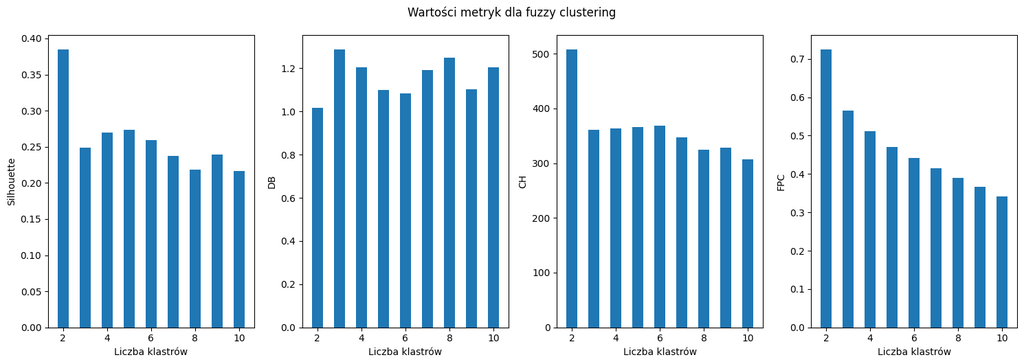

```python
fig, axs = plt.subplots(1, 4, figsize=(15, 5))
for idx, metric in enumerate(['Silhouette', 'DB', 'CH', 'FPC']):
    axs[idx].bar(range(2,11), fuzzy_model_metrics[metric], width = 0.5)
    axs[idx].set_xlabel('Liczba klastrów')
    axs[idx].set_ylabel(metric)

fig.tight_layout()
fig.suptitle('Wartości metryk dla fuzzy clustering', y=1.05)
plt.show()
```

## Wnioski

Najlepsze wyniki dla modelu klastrowania 'miękkiego' zdecydowanie zwraca nam podział na dwa klastry. Wnioski bazujące na wartościach metryk potwierdza również współczynnik Fuzzy Partition Coefficient, który po zmaksymalizowaniu, określa najlepsze opisanie danych.

# ZAD 4

Dla zbioru danych circle.csv proszę, wykorzystując wszystkie (za wyjątkiem c-means) poznane do tej pory algorytmy klasteryzacyjne, podjąć kilka prób dopasowania jak najlepszego modelu, za każdym razem oceniając rozwiązanie z użyciem dedykowanych do tego metryk. Który z algorytmów najlepiej radzi sobie z takim układem danych i dlaczego? Proszę przedstawić wyniki również w formie odpowiednich wizualizacji.

```python
df = pd.read_csv('/content/drive/My Drive/Colab Notebooks/Lab06/circle.csv',sep = ',')
df.describe()
```

|  | x1 | x2 |
| --- | --- | --- |
| count | 1000.000000 | 1000.000000 |
| mean | 0.004336 | 0.000483 |
| std | 0.559414 | 0.561679 |
| min | -1.081727 | -1.099632 |
| 25% | -0.439131 | -0.448021 |
| 50% | 0.005845 | 0.001042 |
| 75% | 0.440670 | 0.426588 |
| max | 1.078307 | 1.116832 |

Nie ma potrzeby normalizować danych.

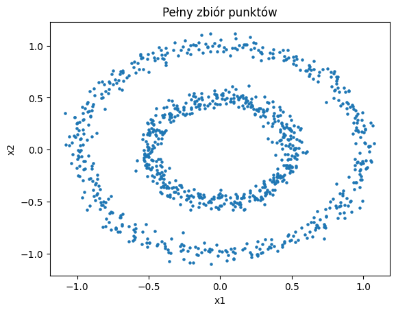

```python
plt.scatter(df['x1'],df['x2'],s=5)
plt.xlabel('x1')
plt.ylabel('x2')
plt.title(f'Pełny zbiór punktów')
plt.show()
```

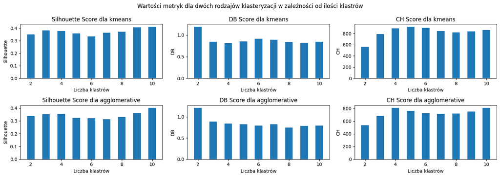

```python
d = {name : {'Silhouette':[], 'DB':[], 'CH':[] } for name in ['kmeans', 'agglomerative']}

for nr_clusters in range(2,11):
  model_kmeans = KMeans(n_clusters = nr_clusters)
  model_kmeans.fit(df)
  labels = model_kmeans.labels_
  d['kmeans']['Silhouette'].append(metrics.silhouette_score(df, labels))
  d['kmeans']['DB'].append(metrics.davies_bouldin_score(df, labels))
  d['kmeans']['CH'].append(metrics.calinski_harabasz_score(df, labels))

  model_agglomerative = AgglomerativeClustering(n_clusters=nr_clusters)
  model_agglomerative.fit(df)
  labels = model_agglomerative.labels_
  d['agglomerative']['Silhouette'].append(metrics.silhouette_score(df, labels))
  d['agglomerative']['DB'].append(metrics.davies_bouldin_score(df, labels))
  d['agglomerative']['CH'].append(metrics.calinski_harabasz_score(df, labels))

fig, axs = plt.subplots(2, 3, figsize=(15, 5))
for idx, metric in enumerate(['Silhouette', 'DB', 'CH']):
    axs[0, idx].bar(range(2,11), d['kmeans'][metric], width = 0.5)
    axs[1, idx].bar(range(2,11), d['agglomerative'][metric], width = 0.5)

    axs[0, idx].set_title(f'{metric} Score dla kmeans')
    axs[1, idx].set_title(f'{metric} Score dla agglomerative')
    for row in range(2):
        axs[row, idx].set_xlabel('Liczba klastrów')
        axs[row, idx].set_ylabel(metric)

fig.tight_layout()
fig.suptitle('Wartości metryk dla dwóch rodzajów klasteryzacji w zależności od ilości klastrów', y=1.05)
plt.show()
```

## Wnioski

Wartości metryk odznaczają się dla ilości klastrów: 4 albo 10 na tle pozostałych. Są najlepsze.

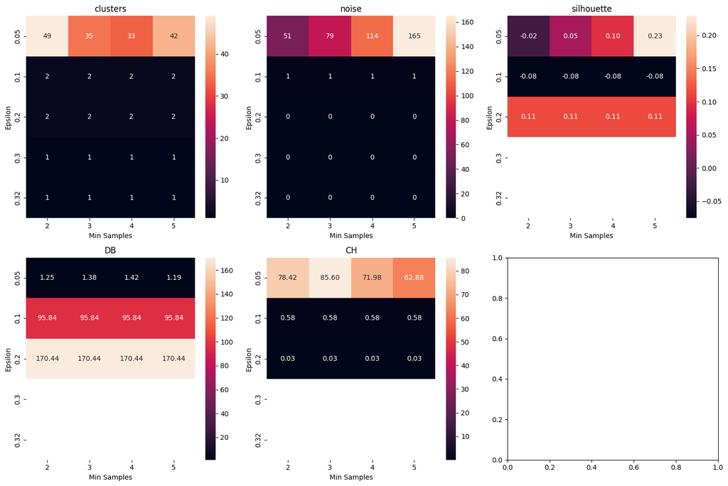

```python
epsilons = [0.05, 0.1, 0.2, 0.3, 0.32]
min_samples = [2, 3, 4, 5]
results = {}

for epsilon in epsilons:
    results[epsilon] = {}
    for min_sample in min_samples:
        model_dbscan = DBSCAN(eps=epsilon, min_samples=min_sample)
        model_dbscan.fit(df)
        labels = model_dbscan.labels_
        n_clusters_ = len(set(labels)) - (1 if -1 in labels else 0)
        n_noise_ = list(labels).count(-1)

        results[epsilon][min_sample] = {'clusters': n_clusters_, 'noise': n_noise_}

        if n_clusters_ > 1:
            results[epsilon][min_sample]['silhouette'] = metrics.silhouette_score(df, labels)
            results[epsilon][min_sample]['DB'] = metrics.davies_bouldin_score(df, labels)
            results[epsilon][min_sample]['CH'] = metrics.calinski_harabasz_score(df, labels)
        else:
            results[epsilon][min_sample]['silhouette'] = None
            results[epsilon][min_sample]['DB'] = None
            results[epsilon][min_sample]['CH'] = None

fig, axs = plt.subplots(2, 3, figsize=(15, 10))
metrics_to_plot = ['clusters', 'noise', 'silhouette', 'DB', 'CH']
axs_flat = axs.flatten()

for i, metric in enumerate(metrics_to_plot):
    data = np.zeros((len(epsilons), len(min_samples)))
    for x, epsilon in enumerate(epsilons):
        for y, min_sample in enumerate(min_samples):
            data[x, y] = results[epsilon][min_sample].get(metric, np.nan)
    heatmap(data, annot=True, fmt=".2f" if metric in ['silhouette', 'DB', 'CH'] else ".0f", xticklabels=min_samples, yticklabels=epsilons, ax=axs_flat[i])
    axs_flat[i].set_xlabel('Min Samples')
    axs_flat[i].set_ylabel('Epsilon')
    axs_flat[i].set_title(f'{metric}')

plt.tight_layout()
plt.show()
```

## Wnioski

Algorytm DBSCAN gorzej radzi sobie z tym zbiorem danych. Dla wielu kombinacji współczynników wprowadzanych do modelu, realizuje tylko jeden klaster. Realizuje również podział na dwa klastry w wielu przypadkach, jednak on zazwyczaj zwraca niezadowalające wartości metryk.

Na podstawie wyników dla różnych rodzajów algorytmów klasteryzacji oraz różnych współczynników rządzących tymi algorytmami, przedstawię podział na 4 klastry za pomocą k-means oraz klastrowania hierarchicznego. Dodatkowo, przedstawię klasteryzację za pomocą dbscan z parametrami eps = 0.05 oraz min_samples = 5, która moim zdaniem najlepiej sobie poradziła, ze względu na wartości metryk, zwracając 42 klastry.

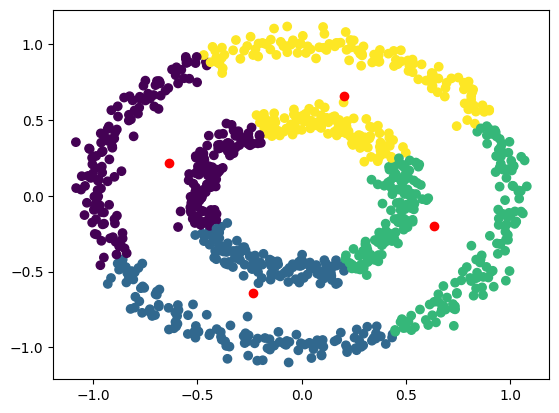

```python
model_kmeans = KMeans(n_clusters = 4)
model_kmeans.fit(df)
plt.scatter(df['x1'],df['x2'],c=model_kmeans.labels_)
plt.scatter(model_kmeans.cluster_centers_[:,0], model_kmeans.cluster_centers_[:,1], c='red')
plt.show()
```

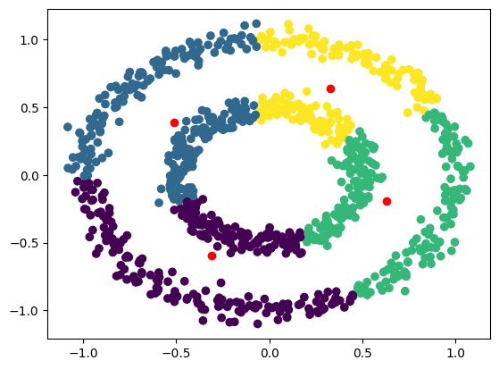

```python
model_agglomerative = AgglomerativeClustering(n_clusters=4)
model_agglomerative.fit(df)

cluster_centers = []
for cluster_label in range(4):
    cluster_points = df[model_agglomerative.labels_ == cluster_label]
    cluster_center = cluster_points[['x1', 'x2']].mean(axis=0)
    cluster_centers.append(cluster_center)
cluster_centers = np.array(cluster_centers)

plt.scatter(df['x1'], df['x2'], c=model_agglomerative.labels_)
plt.scatter(cluster_centers[:, 0], cluster_centers[:, 1], c='red')
plt.show()
```

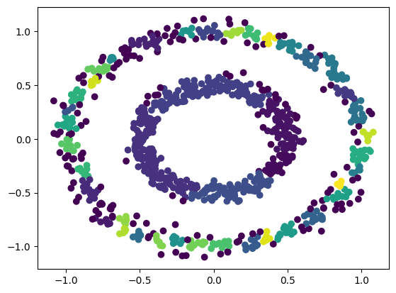

```python
model_dbscan = DBSCAN(eps=0.05, min_samples=5)
model_dbscan.fit(df)
plt.scatter(df['x1'],df['x2'],c=model_dbscan.labels_)
plt.show()
```

Mimo najlepszych wartości metryk, ta klasteryzacja nie ma sensu wizualnego, dlatego do wybiorę model, który dzieli zbiór na dwa klastry.

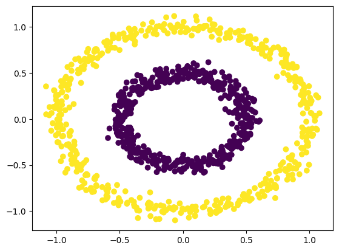

```python
model_dbscan = DBSCAN(eps=0.2, min_samples=4)
model_dbscan.fit(df)
plt.scatter(df['x1'],df['x2'],c=model_dbscan.labels_)
plt.show()
```

```python
print(f'Podobieństwo kmeans oraz agglomerative: {metrics.rand_score(model_kmeans.labels_, model_agglomerative.labels_)}')
```

```
Podobieństwo kmeans oraz agglomerative: 0.9175635635635636
```

## Wnioski

Klasteryzacje przeprowadzone za pomocą algorytmów k-means oraz klasteryzacji aglomeracyjnej dały bardzo zbliżone rezultaty. Potwierdza to wysoka wartość Indeksu Randa obliczona dla etykiet przypisanych przez te modele.

Jednocześnie, oba te algorytmy podzieliły zbiór danych w zupełnie inny sposób niż algorytm DBSCAN. Pomimo że DBSCAN uzyskał niższe wartości metryk w porównaniu do dwóch pozostałych metod, to sposób podziału, który zaproponował, może być satysfakcjonujący w pewnych sytuacjach. Warto zauważyć, że k-means i klasteryzacja aglomeracyjna nie są w stanie dokonać takiego podziału, który polega na identyfikacji wewnętrznego i zewnętrznego okręgu.

Zatem odpowiedzią na pytanie: który z algorytmów najlepiej radzi sobie z takim układem danych, będzie: to zależy od tego, co chcemy osiągnąć. Np. z algorytmu k-means algo agglomerative skorzystamy, jeżeli będziemy chcieli dokonać segmentacji klientów na podstawie ich preferencji zakupowych, natomiast algorytmu DBSCAN użyjemy, gdy będziemy chcieli zidentyfikować pacjentów z grupą ryzyka, którzy wykazują nieprawidłowe wyniki badań.